# *Delfinus mendax* in the Acme Archipelago

A simple CKMR model based on POPs

```r
library(dplyr) # for the tutorial

## CKMR libraries
library(mvbutils) # various low-level utilities, eg cq()
library(offarray) # arrays/vectors don't have to start at 1 any more! Freedom!
library(debug) # so we can watch the fun
library(atease)

## for plotting:
library(ggplot2)
library(cowplot); theme_set(theme_cowplot(font_size=10))
library(colorspace)
library(patchwork)
library(tidyr)

source('../ckmr_funs.r') # tutorial functions
source('../plonk/turn_off_bc.r') # turn-off the byte-compiler (cf. offarray)
agemat <- 5 # age at maturity for this species (also in samp_delfi_A@public$Amat)
```

# Species overview

Pinocchio’s dolphin (*Delfinus mendax*) is a long-lived odontocete found in several large, isolated, genetically-distinct coastal populations. It is easily identified by its often-elongated rostrum. It is largely solitary with no sexual dimorphism. It has one large tooth, retained through life; four milk-teeth at birth, one lost annually until maturity at age 5 (both sexes); females have one calf per year thereafter.

Pinocchio’s Dolphin gets taken as bycatch throughout its range, in gillnets and sometimes in other gears. There appears to be strong selectivity towards younger animals (based on age distribution of bycatch, vs. of apparently-natural strandings). Gear-naivety is one possible explanation, but another is that a longer rostrum is actually protective, since it gives the animal more warning before the fins (the part most vulnerable to entanglement) encounters the gillnet.

Heavy bycatch led to severe population reductions a couple of decades ago. Gear modifications have since reduced the rate, and there is a suggestion that some recovery may be taking place. In several populations, scientists/managers had the foresight to start genetic-sampling of bycatch a few years ago, so that CKMR is now a good option.

# Available samples

The samples collected for Pinocchio’s dolphin are in the list object `samp_delfi_A` under slots `Samps`:

```r
load( '../samp_delfi_A.rda') # object samp_delfi_A
# keeping females only for this exercise:
samp_delfi_A <- subset_samples(samp_delfi_A, Sex=='F')

head(samp_delfi_A$Samps, 10)
```

```
                        Me Sex    Y  A
2  Puvis-Nonob-Dikot-zozus   F 2017 19
3  Suvit-Jamok-Mabof-zagik   F 2015 15
7  Tosip-Pujid-Fagud-dasup   F 2015 14
10 Nijob-Rodit-Vadiz-patuh   F 2015 13
15 Kukav-Bofat-Juzug-dupit   F 2015 12
16 Zovik-Sihum-Famuf-bijut   F 2016 13
17 Bator-Gikub-Zovum-kukiv   F 2015 12
18 Sazig-Kuzof-Tugup-fatug   F 2015 12
22 Favam-Sahab-Dunog-rarov   F 2017 14
23 Dujut-Fakif-Kihim-fabij   F 2017 14
```

There are `nrow(samp_delfi_A$Samps)` (9691) invidivual samples (juveniles and adults) for which sex has been recorded (`Sex`, females only) and age estimated (`A`, from dental records).

```r
nrow(samp_delfi_A$Samps)
```

```
[1] 9691
```

The sampling year in `Samps` is recorded in column `Y` and goes from Year `min(samp_delfi_A$Samps$Y)` (2015) to Year `min(samp_delfi_A$Samps$Y)` (2020).

The first column (`Me`) is a unique identifier for each individual consisting of four words—the first and fourth are unique to the individual and the second and third are the first component of the individual’s mother and father, respectively. So, you can use them to find (or verify) parent-offspring pairs.

*NB: you’ll be reassured to know—I was—that Mark didn’t come up with an infinite list of weird syllabled words for the purpose of simulating pedigree—each word is called a proquint and is designed to be a pronounceable unique identifier, (see more here)[https://github.com/dsw/proquint].*

Before we have a look at the samples, we’ll first create two columns `poss_par` and `poss_off` as booleans to identify each record as a potential “parent” or “offspring”. Since age-at-maturity is strictly 5, we can classify all individuals of age 4 or less as possible offsprings, and individuals of age 5 or more as possible parents.

```r
samp_delfi_A$Samps$poss_off <- samp_delfi_A$Samps$A < agemat
samp_delfi_A$Samps$poss_par <- samp_delfi_A$Samps$A >= agemat
```

From there, we can look at the number of adults and offsprings that were sampled for each sampling year by adult age:

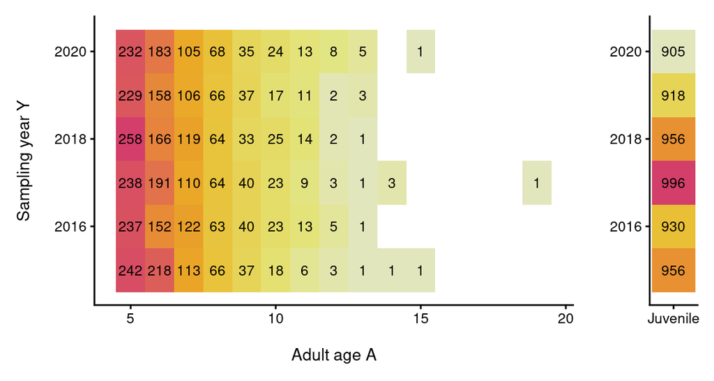

Number of adults (left) and juveniles (right) sampled each year. For adults, the counts are also allocated by the measured adult age.

```r
# Aggregate samples by age / birth year / maturity year
parentcnts <-  samp_delfi_A$Samps %>% filter(poss_par) %>%
    group_by(Y, A) %>% tally() %>% mutate(lab='Adult age')

s1 <- ggplot(parentcnts, aes(A, Y, fill=n)) + geom_tile(show.legend=FALSE) +
    scale_fill_gradientn(colours=rev(heat_hcl(40))) +
    geom_text(aes(label=n), size=3) +
    xlab('\nAdult age A') + ylab('Sampling year Y\n')

offsprngcnts <-  samp_delfi_A$Samps %>% filter(poss_off) %>%
    group_by(Y) %>% tally()

s2 <- ggplot(offsprngcnts, aes(1, Y, fill=n)) + geom_tile(show.legend=FALSE) +
    scale_fill_gradientn(colours=rev(heat_hcl(40))) +
    geom_text(aes(label=n), size=3) + scale_x_continuous(breaks=1, label='Juvenile') +
    xlab('\n') + ylab('')

s1 + s2 + plot_layout(nrow=1, widths=c(10, 1))
```

Base R:

```r
parentcnts <- with(samp_delfi_A$Samps[samp_delfi_A$Samps$poss_par,], table(Y, A))
parentcnts <- as.data.frame(parentcnts, responseName = 'n')
parentcnts$lab <- 'Adult Age'

offsprngcnts <- with(samp_delfi_A$Samps[samp_delfi_A$Samps$poss_off,], table(Y))
offsprngcnts <- as.data.frame(offsprngcnts, responseName = 'n')
```

```r
head(samp_delfi_A$POPs, 10)
```

```
      [,1] [,2]
 [1,]   18  963
 [2,]   18 5756
 [3,]   18 6964
 [4,]   22 3261
 [5,]   25 4542
 [6,]   25 5807
 [7,]   25 6998
 [8,]   38 1577
 [9,]   52 3394
[10,]    8 2171
```

Each row lists the row index of a parent (first column) and an offspring (second column) from the `Samps` dataset:

```r
samp_delfi_A$Samps[c(7, 2224),]
```

```
                          Me Sex    Y  A poss_off poss_par
17   Bator-Gikub-Zovum-kukiv   F 2015 12    FALSE     TRUE
4397 Fipud-Takip-Vizah-dubip   F 2020  9    FALSE     TRUE
```

NB: if we want to be precise, the POPs are actually MOPs, or even, MDPs—Mother-Daughter-Pairs. But we’ll keep calling them POPs below.

# Data preparation

We first summarise the sampling data in order to generate the objects we need to compute the expected number of POPs in our dataset. Eventually, we will end up computing the probability, for each possible parent $j$, that they are the parent of an offspring $i$, given what we know about them (“the covariates”) (see “Modelling framework” below). For now, we start by exploring our samples in order to understand how the dataset gets broken down to generate quantities of interest for CKMR.

Let’s dig a bit into the probability of observing a POP. In order to be a possible parent to a given juvenile, you need, at the very least:

- to have still been alive when the juvenile was born
- to have been mature when the juvenile was born

The first item is given to us by the year of sampling. Since samples for Pinocchio’s dolphin come from (dead) bycaught individuals in the fishery, an adult cannot be the parent of a juvenile born in a year after it was sampled. The second item can be derived from the age of the adult at sampling, as that will give us the birth year, and, if we know age-at-maturity (as we do here), the year at which the adult started contributing to the offspring pool.

*NB: For Pinocchio’s dolphin maturity is knife-edge at age 5, which simplifies things greatly. In most species, the switch to maturity would be spread over a few years.*

The adult dataset can be re-arranged to better show the distribution of these key quantities (adult age, birth and maturity years) in our dataset throughout our sampling years:

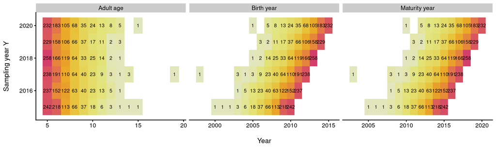

Distribution of adult counts by sampling year vs. adult age (left), adult birth year (center) and adult maturity year (right).

```r
samp_delfi_A$Samps$B <- with(samp_delfi_A$Samps, Y - A) # add birth year B

# Aggregate samples by age / birth year / maturity year
parentcnts <-  samp_delfi_A$Samps %>% filter(poss_par) %>%
    mutate(X=A) %>% group_by(Y, X) %>% tally() %>% mutate(lab='Adult age')
parentcntsby <-  samp_delfi_A$Samps %>% filter(poss_par) %>% mutate(X=B) %>%
    group_by(Y, X) %>% tally() %>% mutate(lab='Birth year')
parentcntsmat <-  samp_delfi_A$Samps %>% filter(poss_par) %>%
    mutate(M=B+agemat, X=M) %>% group_by(Y, X) %>% tally() %>% mutate(lab='Maturity year')
parentsmry <- bind_rows(parentcnts, parentcntsby, parentcntsmat)

ggplot(parentsmry, aes(X, Y, fill=n)) + geom_tile(show.legend=FALSE) +
    scale_fill_gradientn(colours=rev(heat_hcl(40))) +
    geom_text(aes(label=n), size=2.5) +
    facet_wrap(~lab, nrow=1, scales='free_x') +
    xlab('\nYear') + ylab('Sampling year Y\n')
```

Base R:

```r
parentcnts <- with(samp_delfi_A$Samps[samp_delfi_A$Samps$poss_par,], table(Y, A))
parentcnts <- as.data.frame(parentcnts, responseName = 'n')
names(parentcnts)[names(parentcnts) == 'A'] <- 'X'
parentcnts$lab <- 'Adult Age'

parentcntsby <- with(samp_delfi_A$Samps[samp_delfi_A$Samps$poss_par,], table(Y, B))
parentcntsby <- as.data.frame(parentcntsby, responseName = 'n')
names(parentcntsby)[names(parentcntsby) == 'B'] <- 'X'
parentcntsby$lab <- 'Birth year'

tmp <- samp_delfi_A$Samps[samp_delfi_A$Samps$poss_par,]
tmp$X <- tmp$B + agemat # maturity year
parentcntsmat <- with(tmp, table(Y, X))
parentcntsmat <- as.data.frame(parentcntsmat, responseName = 'n')
parentcntsmat$lab <- 'Maturity year'

parentsmry <- rbind(parentcnts, parentcntsby, parentcntsmat)
parentsmry <- parentsmry[parentsmry$n > 0, ]
```

The key comparison for Pinocchio’s dolphin is whether an adult was mature and alive the year a juvenile was born. We can visualise this by directly juxtaposing the distribution of adult maturity and sampling years onto the distribution of juvenile birth years:

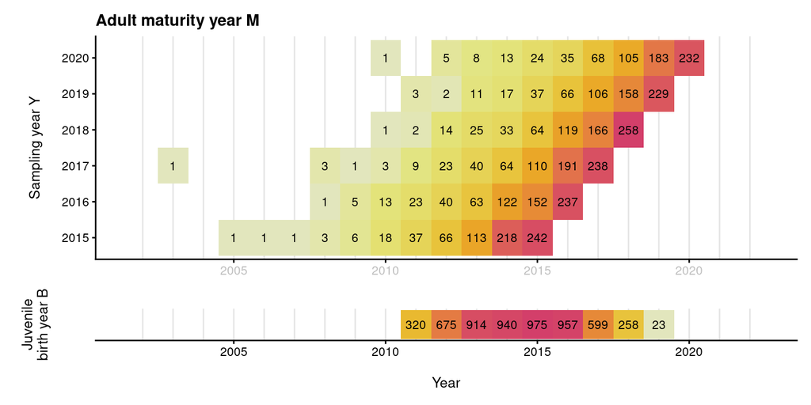

Comparison of adult counts distributed between sampling years and maturity years, and juvenile birth year.

```r
xlms <- c(2002, 2022)

p3 <- ggplot(parentcntsmat, aes(X, as.factor(Y), fill=n)) +
    geom_vline(xintercept=xlms[1]:xlms[2], colour='grey90') +
    geom_tile(show.legend=FALSE) +
    scale_fill_gradientn(colours=rev(heat_hcl(40))) + geom_text(aes(label=n), size=3) +
    theme(axis.text.x=element_text(colour='grey')) +
    coord_cartesian(clip='off') +
    ylab('\nSampling year Y\n') + xlab('') + ggtitle('Adult maturity year M')

offsprcnts <-  samp_delfi_A$Samps %>% filter(poss_off) %>% group_by(B) %>% tally()

o1 <- ggplot(offsprcnts, aes(y=1, (B), fill=n)) +
    geom_vline(xintercept=xlms[1]:xlms[2], colour='grey90') +
    geom_tile(show.legend=FALSE) +
    scale_fill_gradientn(colours=rev(heat_hcl(40))) +
    geom_text(aes(label=n), size=3) +
    xlab('\nYear') + ylab('Juvenile\nbirth year B') +
    coord_cartesian(clip='off') +
    theme(axis.text.y=element_blank(), axis.line.y=element_blank(),
          axis.ticks.y=element_blank())

p3 +
    xlim(xlms + c(-0.5, 0.5)) + o1 + xlim(xlms + c(-0.5, 0.5)) + plot_layout(ncol=1, heights=c(7, 1))
```

Base R:

```r
offsprcnts <- with(samp_delfi_A$Samps[samp_delfi_A$Samps$poss_off,], table(B))
offsprcnts <- as.data.frame(offsprcnts, responseName = 'n')
```

At this stage, we have no other information that would allow us to differentiate the probability of adult $i$ being the parent of offspring $j$, other than the year of sampling, the age of the adult when sampled (which gives us the year when they were mature), and the birth date of the juveniles. Therefore, we can aggregate our adults according to those variables and make comparisons across the resulting strata, instead of making pairwise comparisons between each adult and juvenile samples. This is more efficient than looping through 22813830 pairwise comparisons (i.e. the number of adults $\times$ the number of juveniles).

So, we want to compute the probability that a female of age $A$ sampled in year $Y$ is the mother of a juvenile of birth year $B$, given the number of juveniles produced in year $B$.

The exercise code `fit_delfi_A.r` implements this in two steps. First, prior to defining and fitting the models, quantities are computed by the function `boring_data_prep_delfi_A` which returns an `environment` object:

```r
# use code from 'generic_lglk_MOP_ideal_mammal' to define likelihood
lglk_delfi_A <- generic_lglk_MOP_ideal_mammal
env <- boring_data_prep_delfi_A(samp_delfi_A, prev_env=environment(lglk_delfi_A))
```

As the model itself is defined in `lglk_delfi_A`, we assign `env` as the environment of `lglk_delfi_A`, which makes the objects defined in `env` accessible to the code executed within `lglk_delfi_A`. The main advantage of doing this is that preliminary computations do not have to be provided as additional arguments to the `lglk_delfi_A` function, or redone from scratch for every model iteration. See [here](https://blog.thatbuthow.com/how-r-searches-and-finds-stuff/) for a more in-depth explanation on how environments work in R.

One of two key quantities computed by `boring_data_prep_delfi_A` is the number of possible pairwise comparisons between adults and juveniles by $Y$-$A$ $\times$ $B$ strata. Here, comparisons are only deemed possible if the adults in $Y$-$A$ were born before the juveniles born in year $B$. The number of possible comparisons is then the product of the number of adults in the $Y$-$A$ stratum and the number of juveniles born in year $B$ (i.e. $B > Y - A$).

Here’s an example (for one sampling year) of how to visualise the comparisons between the offsprings and their parents:

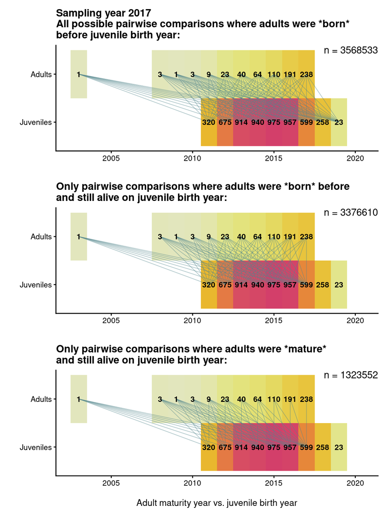

Illustration of different types of pairwise comparisons (lines) between each sampling year—adult age [shown as maturity year] stratum and juvenile birth year.

```r
parentcntsmat <-  samp_delfi_A$Samps %>% filter(poss_par) %>%
    mutate(M=B+agemat) %>% group_by(Y, M) %>% tally() %>% mutate(lab='Maturity')

xl <- range(c(parentcntsmat$M, offsprcnts$B)) + c(-0.5, 0.5)

draw_comp_panel <- function(wsy=25, wcomp='All') { # which sampling year

    # get adults stats and counts for wsy
    oadf <- bind_rows(filter(parentcntsmat,  Y == wsy) %>%
                      mutate(Type = 'Adults', X = M),
                      mutate(offsprcnts, X = B, Type = 'Juveniles')) %>%
        mutate(Type=factor(Type, levels=c('Juveniles', 'Adults'), ordered=TRUE))

    # get plausible parent-offspring matches
    get_compdf <- function(wm) {
        ## to match boring_data_prep_delfi_A,
        ## only retain comparisons where adults were born >= juveniles birth year
        ## cf. n_comp_MOP_BYA
        oo <- offsprcnts %>%
            mutate(M=wm, Y=wsy) %>%
            # define types of pairwise comps
            mutate(All=TRUE,
                   Boring = B >= (M-5) & B <= Y,  # adults alive and born
                   Comp = B >= M & B <= Y) %>%  # adults alive and mature
            mutate(X=M) %>%
            filter((M-5) < B) %>% # filter out adults born after juveniles
            left_join(dplyr::select(filter(oadf, Type == 'Adults'), -B),
                      by=c('X', 'M', 'Y')) %>%
            mutate(Aad=Y-M+agemat)
    }

    compdf <- lapply(oadf$M, get_compdf) %>% bind_rows
    #    numc <- sum(with(filter(compdf, (Y - M - 5) < B), n.x * n.y), na.rm=TRUE)
    numc <- sum(with(filter(compdf, .data[[wcomp]]), n.x * n.y), na.rm=TRUE)
    labs <- c('All'='Sampling year 2017\nAll possible pairwise comparisons where adults were *born*\nbefore juvenile birth year:',
              'Boring'='Only pairwise comparisons where adults were *born* before \nand still alive on juvenile birth year:',
              'Comp'='Only pairwise comparisons where adults were *mature*\nand still alive on juvenile birth year:')

    gg0 <- ggplot(oadf, aes(X, Type, fill=n)) +
        geom_tile(show.legend=FALSE) +
       scale_fill_gradientn(colours=rev(heat_hcl(40))) +
       geom_segment(data=filter(compdf, .data[[wcomp]]), aes(x=M, xend=B, y='Adults', yend='Juveniles', fill=NULL),
                    alpha=0.5, show.legend=FALSE, colour='cadetblue4', size=0.3) +
       geom_text(aes(label=n), fontface=2, size=3) +
       annotate('text', x=Inf, y=Inf, label=paste('n =', numc), vjust=1.1, hjust=1) +
       xlab('') + ylab('') +
       xlim(xl) + ggtitle(labs[wcomp])

    gg0
}

lapply(c('All', 'Boring', 'Comp'), draw_comp_panel, wsy=2017) %>%
    wrap_plots(ncol=1) +
    xlab('\nAdult maturity year vs. juvenile birth year')
```

Base R:

```r
# Untested and possibly very buggey!
tmp <- samp_delfi_A$Samps[samp_delfi_A$Samps$poss_par, ]
tmp$M <- tmp$B + agemat
parentcntsmat <- as.data.frame(with(tmp, table(Y, M)), responseName = 'n')
parentcntsmat$lab <- 'Maturity'

draw_comp_panel <- function(wsy=25, wcomp='All') { # which sampling year

    # get adults stats and counts for wsy
    pp <- parentcntsmat[parentcntsmat$Y == wsy, ]
    pp$Type <- 'Adults'
    pp$X <- pp$M
    offsprcnts$Type <- 'Juveniles'
    offsprcnts$X <- offsprcnts$B

    oadf <- rbind(pp, offsprcnts)
    oadf$Type <- factor(oadf$Type, levels=c('Juveniles', 'Adults'), ordered=TRUE)

    get_compdf <- function(wm) {

        offsprcnts$M <- wm
        offsprcnts$Y <- wsy
        offsprcnts$All <- TRUE
        offsprcnts$Boring <- with(offsprcnts, B >= (M-5) & B <= Y) # adults alive and born
        offsprcnts$Comp <- with(offsprcnts, B >= M & B <= Y) # adults alive and mature
        offsprcnts$X <- offsprcnts$M
        offsprcnts <- offsprcnts[(offsprcnts$M - 5) < offsprcnts$B, ]

        oo <- merge(offsprcnts, oadf[oadf$Type == 'Adults', !(names(oadf)=='B')],
                    by=c('X', 'M', 'Y'), all.x=TRUE) # left-join

        oo$Aad <- with(oo, Y - M + agemat)

 }

    compdf <- do.call(rbind, lapply(oadf$M, get_compdf))
    numc <- sum(with(filter(compdf, .data[[wcomp]]), n.x * n.y), na.rm=TRUE)
    labs <- c('All'='Sampling year 2017\nAll possible pairwise comparisons where adults were *born*\nbefore juvenile birth year:',
              'Boring'='Only pairwise comparisons where adults were *born* before \nand still alive on juvenile birth year:',
              'Comp'='Only pairwise comparisons where adults were *mature*\nand still alive on juvenile birth year:')

    gg0 <- ggplot(oadf, aes(X, Type, fill=n)) +
        geom_tile(show.legend=FALSE) +
       scale_fill_gradientn(colours=rev(heat_hcl(40))) +
       geom_segment(data=filter(compdf, .data[[wcomp]]), aes(x=M, xend=B, y='Adults', yend='Juveniles', fill=NULL),
                    alpha=0.5, show.legend=FALSE, colour='royalblue3') +
       geom_text(aes(label=n), fontface=2, size=3) +
       annotate('text', x=Inf, y=Inf, label=paste('n =', numc), vjust=1.1, hjust=1) +
       xlab('') + ylab('') +
       xlim(xl) + ggtitle(labs[wcomp])

    gg0
}
```

The lines show all possible comparisons that meet the stated requirement. The number in the top-right corner is the total possible number of pairwise comparisons in the sampling year.

The number of possible pairwise combinations is an important quantity as it scales the expected probability of observing a POP.

The number of pairwise comparisons by $Y$-$A$ $\times$ $B$ strata are stored in object `env$n_comp_MOP_BYA` for instances where adults were born before the juvenile birth year (i.e. the top panel of the figure above). You can verify that the numbers match those in `env$n_comp_MOP_BYA`, and also examine individual counts by querying cells within the offarray object, e.g.:

```r
env$n_comp_MOP_BYA[2011, 2017, 19]
```

```
, , Aad = 19

         Yad
Bju       [,2017]
  [2011,]     320
```

```r
sum(env$n_comp_MOP_BYA[, SLICE = 2017, ])
```

```
[1] 3568533
```

will show the possible number of pairwise comparisons between juveniles born in 2011 and adults sampled in 2017 of age 19, and the total number of pairwise comparisons for adults sampled in 2017.

Note that objects of class `offarray` are indexed based on the name of the dimensions, not the cell positions. Use `dimseq(env$n_comp_MOP_BYA)` to view the name of the dimensions.

The other important quantity computed by `boring_data_prep_delfi_A` is the count of observed POPs by $Y$-$A$-$B$ stratum, `n_MOP_BYA`:

```r
dimseq(env$n_MOP_BYA)
```

```
$Bju
[1] 2011 2012 2013 2014 2015 2016 2017 2018 2019

$Yad
[1] 2015 2016 2017 2018 2019 2020

$Aad
 [1]  5  6  7  8  9 10 11 12 13 14 15 16 17 18 19
```

This can be visualised for each sampling year as follows:

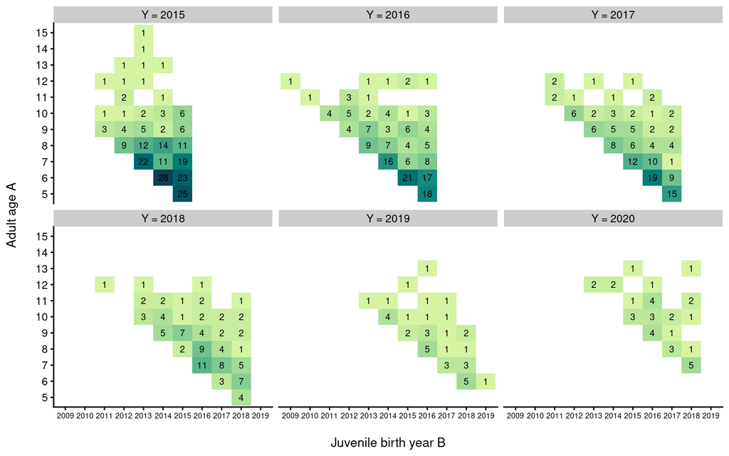

Distribution of detected POPs across sampling years, adult ages, and juvenile birth years.

```r
popdf <- with(samp_delfi_A$Samps,
              data.frame(Y=Y[samp_delfi_A$POPs[,1]],
                         A=A[samp_delfi_A$POPs[,1]],
                         B=B[samp_delfi_A$POPs[,2]]))

npop <- popdf %>% group_by(Y, A, B) %>% tally %>%
    mutate(Y=paste('Y =', Y))

ggplot(npop, aes(as.factor(B), as.factor(A), fill=n)) +
    geom_tile(show.legend=FALSE) +
    scale_fill_gradientn(colours=rev(sequential_hcl(40, 'Emrld'))) +
    geom_text(aes(label=n), size=2.5) +
    facet_wrap(~Y) +
    ylab('Adult age A\n') + xlab('\nJuvenile birth year B') +
    theme(axis.text.x=element_text(size=6))
```

Base R:

```r
npop <- with(popdf, table(Y, A, B))
npop <- as.data.frame(npop, responseName = 'n')
npop$Y <- paste('Y =', npop$Y)
```

Other objects computed by `boring_data_prep_delfi_A` include:

```r
env$Yad_range # the range of sampling years for adults
```

```
[1] 2015 2016 2017 2018 2019 2020
```

```r
env$Aad_range # the range of adult ages sampled
```

```
 [1]  5  6  7  8  9 10 11 12 13 14 15 16 17 18 19
```

```r
env$Bju_range # the range of juvenile birth years observed
```

```
[1] 2011 2012 2013 2014 2015 2016 2017 2018 2019
```

Use the function `ls` to view objects stored in `env`:

```r
ls(env)
```

```
 [1] "A"              "Aad_range"      "adid"           "Amat"
 [5] "AMAX"           "B"              "Bju_range"      "juvid"
 [9] "n_comp_MOP_BYA" "n_MOP_BYA"      "POP_df"         "rPOPs"
[13] "Y"              "y0"             "Yad_range"      "years"
```

# Modelling framework

Our end goal is to estimate population size per year, $N_y$, for Pinocchio’s dolphin. We do this by maximising the likelihood of the observed parent-offspring-pairs given our population dynamics model and what we know about our samples (e.g., the year the juveniles were born in, the number of samples, etc.). As we are only including female samples, we are focusing on female population dynamics.

Let’s first define our population model.

For Pinocchio’s dolphin, reproductive output is independent of age, and of 1 offspring per year, such that population dynamics can be described as:

$$N_t = N_0 e^\lambda$$

(Population numbers are low at the moment, so we can assume exponential growth).

Since the population abundance directly scales with the probability of observing an Parent-Offspring-Pair, we can work backwards from the estimated probability of $Pr(POPs|N_0, \lambda)$ to gain an estimate of $N_y$ (with a few assumptions…!).

The steps in the general CKMR modelling framework are:

- Unpack model parameters
- Predict population dynamics given parameters
- Compute “true” expected probability of a POP
- Compute actual expected probability of a POP given uncertainty about covariates
- Return the likelihood of the observed number of POPs

(We can ignore step 4 since age is measured with 100% accuracy in the Acme Archipelago.)

These steps are implemented by the function `generic_lglk_MOP_ideal_mammal` which we’ve renamed `lglk_delfi_A` in this exercise. We go through each of these in the next section by examining key parts of the `generic_lglk_MOP_ideal_mammal`. The full code of `generic_lglk_MOP_ideal_mammal` is defined in `ckmr_funs.r`.

# Model launch

The model is launched in `fit_delfi_A.r` by first defining the environment of `lglk_delfi_A` as `env`, which means that the quantities that were computed in the boring data prep step are accessible within the `lglk_delfi_A` local environment. We then fit the model in `lglk_delfi_A` with the function `nlminb`.

```r
environment( lglk_delfi_A) <- env # include objects from preparation step to likelihood function environment
```

The full model is defined in `generic_lglk_MOP_ideal_mammal` in `ckmr_funs.r`, but we’ll go through the key steps below.

The first year of the model is the earliest birth year of juveniles sampled (e.g. “1993” if juveniles were born in 1993, 1994, and 1997—here, “2011”—see also `env$Bju_range`), the last year of the model is the last year an adult was sampled (here, “2020”). This range is also stored in model object `env$years`.

`lglk_delfi_A` follows the framework defined above. First, we start by back-transforming the two parameters of the population model, $N_0$ and $\lambda$:

```r
## Unpack parameters
Nfad_y0 <- exp(params[1])
RoI <- params[2]
```

We then compute $N_Y$ from years 2011 to 2020:

```r
  N <- offarray( 0, first=min( years), last=max( years))
  N[] <- Nfad_y0 * exp( RoI * (years-y0))
```

Next, we compute the probability of a parent-offspring-pair given our covariates (offspring birth year, adult age at sampling and adult sampling year).

Since each Pinocchio’s dolphin female produces one offspring per year once mature, the number of recruits every year is the number of females in the population in year *Y*, so the probability that any recruit born in year $B$ is the offspring of a possible parent female is $\frac{1}{N_B}$.

The probability that a POP is detected in year *Y* for any females of age *A* and juveniles born in year *B* is thus:

- the probability that a female of that age-year strata was still alive in year $B$ (0/1) $\times$
- the probability that a female of that age-year strata was mature in year $B$ (0/1) $\times$
- the inverse of the number of offspring produced in year *B* ($\frac{1}{N_B}$).

We thus loop through each combination of $Y$-$A$ and $B$ to compute this probability:

```r
  # Ideal kinship probs, i.e. if know all important covariates perfectly
  Pr_MOP_BYA <- autoloop( Bju=Bju_range, Yad=Yad_range, Aad=Aad_range, {
    Bad <- Yad - Aad
    ( Bju <= Yad ) *          # was adult still alive at B[ju] ?
    ( Bju >= Amat + Bad ) *   # was adult mature at B[ju] ?
    ( 1/N[ Bju])              # adult's ERO at B[ju], divided by TRO that year
  })
```

From this, we can predict the number of expected parent-offspring pairs detected given the sample size in each strata. The function `lk_delfi_A` outputs the (Poisson) likelihood of observing $n_{Y, A, B}$ POPs given the expected $n$ POPs for that stratum:

```r
  lglk <- MAKE_FINITE( # anti-infinity guard
      sum( dpois( n_MOP_BYA, lambda=n_comp_MOP_BYA * Pr_MOP_BYA, log=TRUE))
    )
```

```r
# test some starting values for logNad and RoI
starto <- c( log( 100000), 0.01)
initest <- lglk_delfi_A( starto)

# fit model:
fitto <- nlminb( starto, NEG( lglk_delfi_A))
```

The values of $N_0$ and $\lambda$ that optimise the likelihood are 1.02782^{4} and 0.0121. Let’s compare that to the true values that were used when simulating the dataset:

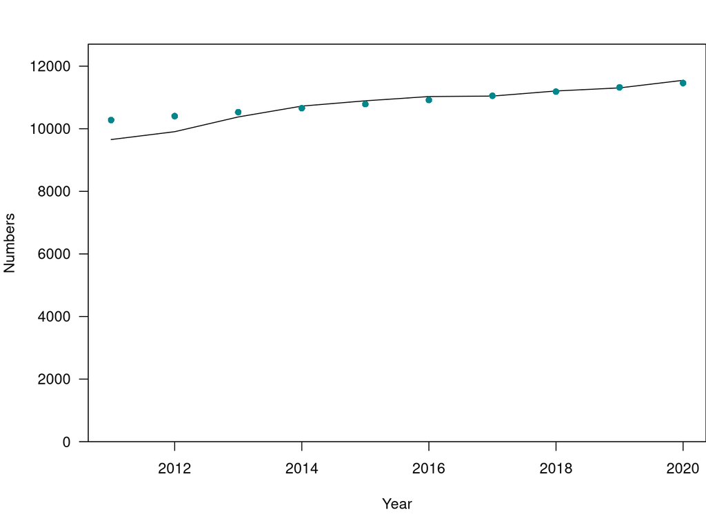

```r
Nfad_y0 <- exp(fitto$par[1])
RoI <- fitto$par[2]
N_y <- Nfad_y0 * exp( RoI * (env$years - env$y0))

# get true value for female population 'F':
tru_Nadf <- apply(samp_delfi_A@secret$N_sya['F', env$years, agemat:40], 2, sum)

maxyplot <- max( c( tru_Nadf, N_y))
par(mai=c(1, 1, 0.5, 0))
plot( env$years, tru_Nadf, type='l', ylim=c( 0, 1.1*maxyplot),
     xlab = 'Year', ylab='Numbers\n', las=1, yaxs='i')
points( env$years, env$N, col='turquoise4', pch=16)
```

Not bad! There are more diagnostics and options for exploring results in `fit_delphi_A.r`.

## Diagnostics

Diagnostics for CKMR can be tricky as there is often a very small amount of observed POPs.

This example actually contains a huge amount of POPs compared to what we would usually observe, so we can compare observed vs. expected POPs for each sampling year and juvenile birth year.

The expected POPs are:

```r
round(sumover(with(env, n_comp_MOP_BYA * Pr_MOP_BYA), c('Bju', 'Aad')), 1)
```

```
Yad
[2015] [2016] [2017] [2018] [2019] [2020]
 136.8  138.1  121.8   85.3   46.6   31.4
```

and the observed POPs are:

```r
sumover(env$n_MOP_BYA, c('Bju', 'Aad'))
```

```
Yad
[2015] [2016] [2017] [2018] [2019] [2020]
   157    128    114     90     36     35
```

If we plot them we can see that prediction appears unbiased with no trend over time.

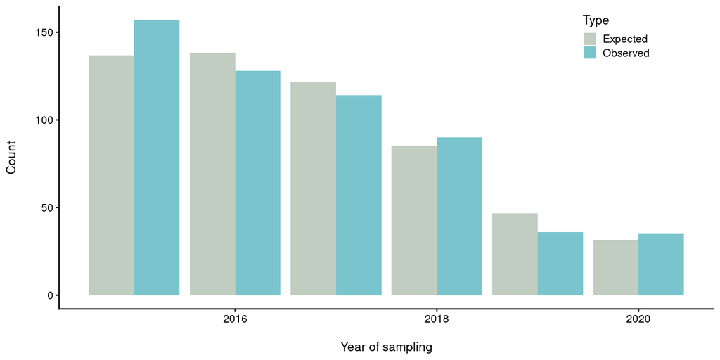

```r
diagdf <- data.frame(sumover(with(env, n_comp_MOP_BYA * Pr_MOP_BYA),
                             c('Bju', 'Aad')),
                     sumover(env$n_MOP_BYA, c('Bju', 'Aad'))) %>%
    dplyr::select(Yad, Expected=response, Observed=response.1) %>%
    gather(Type, Number, Expected:Observed)

ggplot(diagdf, aes(Yad, Number, fill=Type)) +
    geom_bar(stat='identity', position=position_dodge()) +
    scale_fill_manual(values=c('honeydew3', 'cadetblue3')) +
    xlab('\nYear of sampling') + ylab('Count\n') +
    theme(legend.position=c(0.8, 0.9))
```

Base R:

```r
tmp <- data.frame(sumover(with(env, n_comp_MOP_BYA * Pr_MOP_BYA),
                             c('Bju', 'Aad')),
                     sumover(env$n_MOP_BYA, c('Bju', 'Aad')))
tmp <- tmp[, c('Yad', 'response', 'response.1')]

diagdf <- rbind(data.frame(Yad=tmp$Yad,
                           Number=tmp$response,
                           Type='Expected'),
                data.frame(Yad=tmp$Yad,
                           Number=tmp$response.1,
                           Type='Observed'))
```

(NB: If we wanted to do this properly we could do a $\chi^2$-test.

For a normal dataset with less POPs, we would aggregate time-periods instead of inspecting individual years (e.g. first half vs. second half time-series).